# Quarto Assessment MT24

Published

December 13, 2024

# Introduction

The aim of this analysis is to assess whether drought has an impact on the evolution of beak morphology in the medium ground finch, *Geospiza fortis*.

Beak morphology is believed to evolve in response to availability of food and preferred food of a species, in part defined by the niche a species occupies and in part by environmental effects altering what foods are available and in what quantity. Freak events like droughts can create large selection pressures which act on beak morphology, causing evolution in response to changing food sources. In 1977, Daphne Major (an island in the Galapagos archipelago, off the coast of Ecuador) experienced a major drought. This caused changes to and severely limited the food supply on the island, making it such that only large, tough seeds were available for the birds to eat (Boag and Grant, 1981).

Data were collected on beak depth on *G. fortis* before and after the drought; this analysis will examine these data to assess whether there is evidence of the evolution of beak morphology (using beak depth) in response to drought.

The dataset used in this analysis consists of a random sample of 89 finches caught before the drought, and all 89 finches which survived after the drought, in 1978 (Boag and Grant, 1981).

```r
#Loading packages needed for this analysis.
library(Sleuth3)
library(ggplot2)
library(tinytex)
library(arm)
library(rmarkdown)
library(here)
library(renv)
library(dplyr)
library(multcompView)
library(ragg)
library(patchwork)
```

```r
#Investigating data.
head(case0201)
```

```
  Year Depth
1 1976   6.2
2 1976   6.8
3 1976   7.1
4 1976   7.1
5 1976   7.4
6 1976   7.8
```

```r
str(case0201)
```

```
'data.frame':   178 obs. of  2 variables:
 $ Year : int  1976 1976 1976 1976 1976 1976 1976 1976 1976 1976 ...
 $ Depth: num  6.2 6.8 7.1 7.1 7.4 7.8 7.9 8 8.2 8.4 ...
```

```r
summary(case0201)
```

```
      Year          Depth
 Min.   :1976   Min.   : 6.200
 1st Qu.:1976   1st Qu.: 9.100
 Median :1977   Median : 9.900
 Mean   :1977   Mean   : 9.804
 3rd Qu.:1978   3rd Qu.:10.500
 Max.   :1978   Max.   :11.700
```

```r
colnames(case0201)
```

```
[1] "Year"  "Depth"
```

```r
#Preserving raw data as .csv file to keep it safe in event of mutation, and making new data frame which can be modified as necessary.
write.csv(case0201, here("data/finches_raw.csv"))
finches_raw <- read.csv(here("data/finches_raw.csv"))

#Factorising "Year" variable.
finches_raw$Year = as.factor(finches_raw$Year)
str(finches_raw)
```

```
'data.frame':   178 obs. of  3 variables:
 $ X    : int  1 2 3 4 5 6 7 8 9 10 ...
 $ Year : Factor w/ 2 levels "1976","1978": 1 1 1 1 1 1 1 1 1 1 ...
 $ Depth: num  6.2 6.8 7.1 7.1 7.4 7.8 7.9 8 8.2 8.4 ...
```

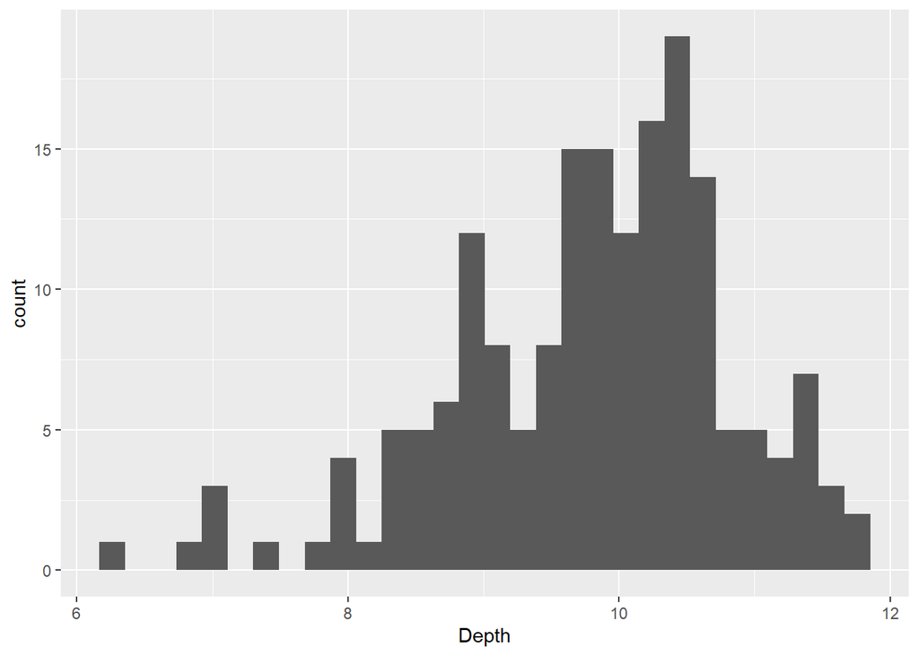

```r
#Histograms to check spread of data- transformations unsuccessful so will use untransformed data.
ggplot(data = finches_raw, aes(x = Depth)) + geom_histogram()
```

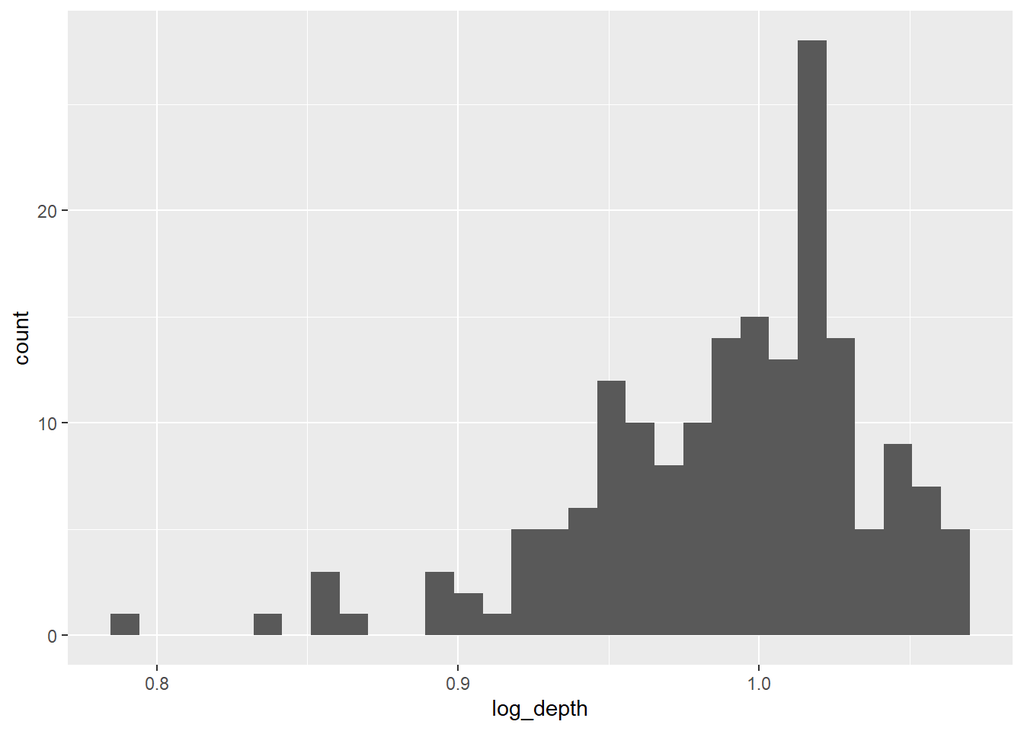

```r
#Codes for log transformation of Depth data and plots histogram of- can see this transformation made data more left-skewed.
log_depth <- log10(finches_raw$Depth)
ggplot(data = finches_raw, aes(x = log_depth)) + geom_histogram()
```

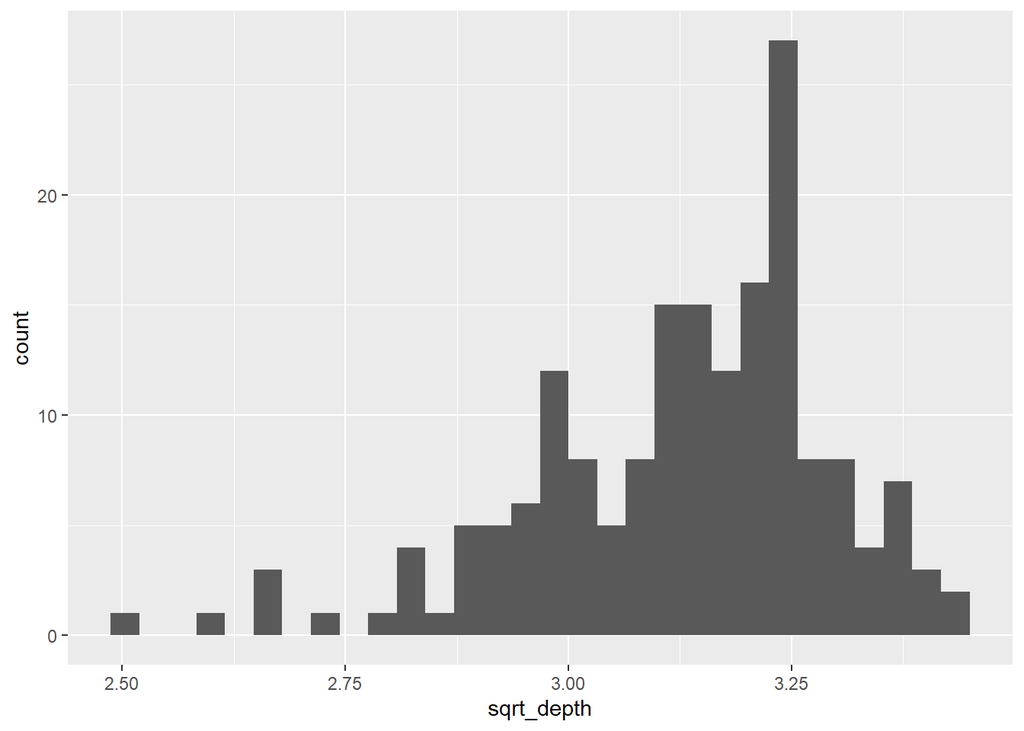

```r
#Codes for square root transformation of Depth dataand plots histogram of- can see this transformation also made data more left-skewed.
sqrt_depth <- sqrt(finches_raw$Depth)
ggplot(data = finches_raw, aes(x = sqrt_depth)) + geom_histogram()
```

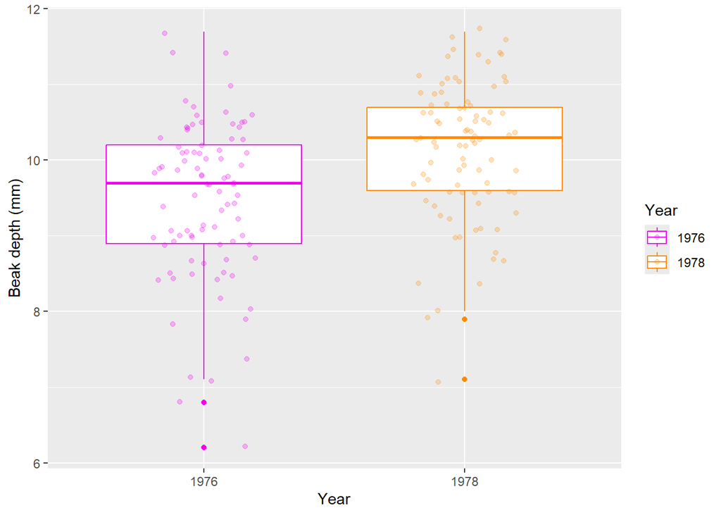

```r
#Setting own colours for each year. This ensures document is colour blind friendly, increasing document accessibility, and more reproducible (as this makes sure each year is always represented by the same colour when colour is specified).
year_colours <- c("1976" = "magenta2", "1978" = "darkorange")

#Plotting exploratory boxplot to see what data look like.
# Added jitter to artificially spread data points to increase their visibility, with random      seed to ensure jitter is the same every time.
# geom_jitter() makes data points visible on graph and spreads them out.
# alpha specifies transparency of datapoints to ensure they do not hide graph.
# position_jitter() allows finer control over how much data points are spread by. Seed makes     figure more reproducible by specifying how data points spread in the same way every time.
# labs() adds own labels to plot.
# scale_colour_manual() specifies which colour each group is assigned, based on year_colours      coded above.
finches_exploratory_figure <- ggplot(data = finches_raw, aes(x=Year,  y=Depth, group = Year)) + geom_boxplot(aes(color = Year)) + geom_jitter(aes(color = Year), alpha = 0.25, position = position_jitter(width = 0.2, seed=0)) + labs (x= "Year", y = "Beak depth (mm)") + scale_colour_manual(values = year_colours)

#Creates results figure created by code above, plotting the encoded graph.
plot(finches_exploratory_figure)
```

# Methods

To analyse how mean beak depth (mm) changes between 1976 and 1978, a one-way ANOVA test will be conducted. This is because there are two distinct populations, and there is a continuous response variable and a categorical explanatory variable.

The null hypothesis is that the difference in mean beak depth between years is equal to 0.

The alternative hypothesis is that the mean difference in beak depth between years is not equal to 0.

The assumption of independent samples is not violated in this analysis, as a random sample is taken in 1976 which is statistically unlikely to include a significant proportion of birds recaptured in 1978 (which would have survived the 1977 drought) (Boag and Grant, 1981). As it is not the same birds represented in both years, the samples are therefore not paired and so can be considered independent for the purpose of this analysis.

NB: Analysis presented here is different from that of the referenced paper.

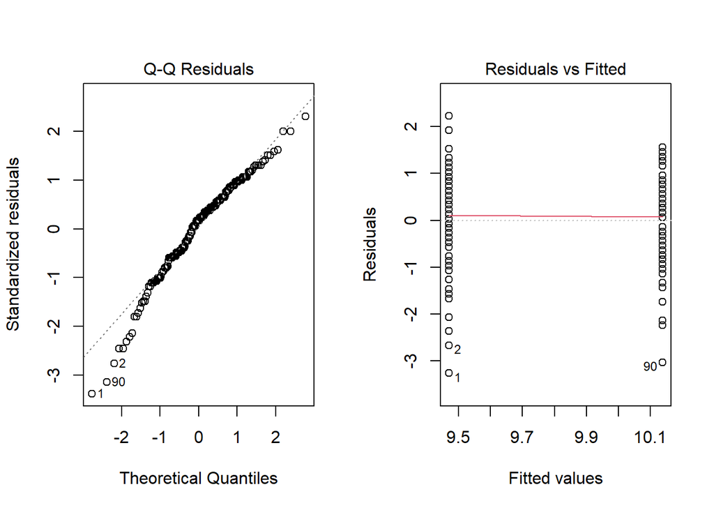

```r
#Creating linear model to test effect of year on beak depth (mm).
finches_model <- lm(Depth ~ Year, data = finches_raw)

#Checking assumptions of one-way ANOVA test are not violated:
#Making multi-panel figure to allow assessment of normality and heteroscedascity of model using par() function.
par(mfrow = c(1,2))

#Verifying normal distribution of samples:
# which=2 specifies QQ plot to compare the data in finches_model to a theoretical normal dataset, to verify data is normally distributed. As points mostly lie on straight line, can assume this sample is normally distributed.
plot(finches_model, which=2)

#Verifying assumption of equal variance between populations (i.e between 1976 and 1978), ensuring homoscedasicity.
# which=1 specifies graph of residual values vs fitted values, to verify population variances are equal between samples.
plot(finches_model, which=1)
```

```r
#Bartlett test also verifies assumption of equal variance, but gives p-value. In this case, p=0.2144 and 0.2144 > 0.05 therefore equal variance between populations and assumption is not violated.
bartlett.test(Depth ~ Year, data=finches_raw)
```

```
    Bartlett test of homogeneity of variances

data:  Depth by Year
Bartlett's K-squared = 1.5412, df = 1, p-value = 0.2144
```

```r
#Running summary of model to assess adjusted R-squared and generate p-value and F-values..
summary(finches_model)
```

```
Call:
lm(formula = Depth ~ Year, data = finches_raw)

Residuals:
    Min      1Q  Median      3Q     Max
-3.2697 -0.5382  0.1618  0.6303  2.2303

Coefficients:
            Estimate Std. Error t value Pr(>|t|)
(Intercept)   9.4697     0.1031  91.812  < 2e-16 ***
Year1978      0.6685     0.1459   4.583 8.65e-06 ***
---
Signif. codes:  0 '***' 0.001 '**' 0.01 '*' 0.05 '.' 0.1 ' ' 1

Residual standard error: 0.973 on 176 degrees of freedom
Multiple R-squared:  0.1066,    Adjusted R-squared:  0.1016
F-statistic: 21.01 on 1 and 176 DF,  p-value: 8.65e-06
```

```r
#Conducting ANOVA on model to establish if there is a significant effect of year on beak depth. Produces anova table.
finch_anova <- aov(finches_model)
summary(finch_anova)
```

```
             Df Sum Sq Mean Sq F value   Pr(>F)
Year          1  19.89  19.889   21.01 8.65e-06 ***
Residuals   176 166.64   0.947
---
Signif. codes:  0 '***' 0.001 '**' 0.01 '*' 0.05 '.' 0.1 ' ' 1
```

```r
#Conducting Tukey test to ascertain which groups are different (this is already known but necessary for subsequent code). Produces Tukey post-hoc multiple comparisons table.
finch_tukey <- TukeyHSD(finch_anova)
print(finch_tukey)
```

```
  Tukey multiple comparisons of means
    95% family-wise confidence level

Fit: aov(formula = finches_model)

$Year
               diff       lwr       upr   p adj
1978-1976 0.6685393 0.3806698 0.9564088 8.6e-06
```

```r
#Creates compact letter display, useful for graphically representing significant differences between groups.
finch_cld <- multcompLetters4(finch_anova, finch_tukey)
print(finch_cld)
```

```
$Year
1978 1976
 "a"  "b"
```

```r
#Creating new table containing information on mean beak depth in each year, the 3rd quantile of each group and what compact letter each group belongs to.
finch_analysed <- group_by(finches_raw, Year) %>%
  summarise(mean = mean(Depth), quant = quantile(Depth, probs = 0.75)) %>%
  arrange(desc(mean))

#Makes new dataframe contaiing information on compact letter display of each group.
finch_cld <- as.data.frame.list(finch_cld$Year)

#Makes new column in finch_analysed dataset containing information on compact letter display for each group (1976 or 1978)
finch_analysed$cld <- finch_cld$Letters

print(finch_analysed)
```

```
# A tibble: 2 × 4
  Year   mean quant cld
  <fct> <dbl> <dbl> <chr>
1 1978  10.1   10.7 a
2 1976   9.47  10.2 b
```

```r
#Shows us what mean values of each group are.
means <- aggregate(Depth ~ Year, finches_raw, mean)
means
```

```
  Year     Depth
1 1976  9.469663
2 1978 10.138202
```

# Results

This one-way ANOVA analysis shows there is a statistically significant difference in mean beak depth between 1976 and 1978.

In 1976, mean beak depth was 9.470mm (3dp) but in 1978 the mean increased to 10.138mm (3dp).

From the summary table for the finch_model, only 10.16% of variation in beak depth is explained by year (adjusted R-squared = 0.1016). This is surprising as it was expected that the year would play a large role in explaining variation in beak depth and suggests there may be other factors influencing this. That said, the F-value for the ANOVA is 21, which is greater than 1 and therefore shows a significant difference between mean beak depth in 1976 and in 1978. The p-value for this analysis was 8.65*10^-6.

The Tukey analysis showed the mean value of beak depth (mm) differed between 1976 and 1978 by 0.669mm (3dp) (95%CI 0.381 to 0.956mm (3dp)). As the 95% confidence intervals do not include 0 (which is what would be expected by the null hypothesis), this shows there is a significant difference between groups. The p-value is 8.6*10^-6, which is also significant.

On the boxplot showing the results of this analysis, the median of each group is represented by the bar across the box; the mean of each group is represented by the dark blue dot. The significant difference between the mean beak depths in each year is shown on the results boxplot, with the compact letter display showing a difference between years. On the graph, there are two groups, a and b, which correspond to 1976 (b) and 1978 (a).

Taking all the above into account, this analysis has shown that the null hypothesis (that there is no difference in mean beak depth between years) can be rejected.

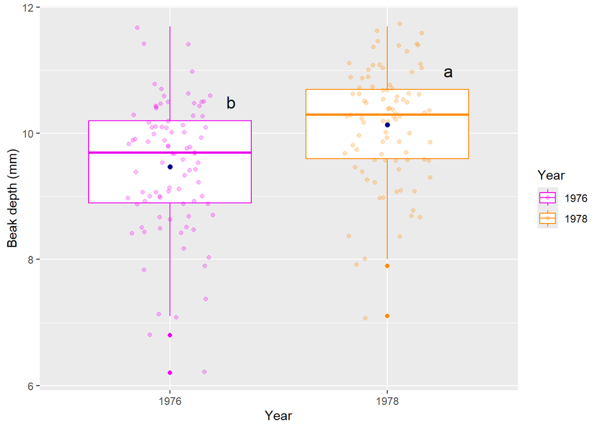

```r
#Plotting results figure incorporating compact letter display gained from analysis. Code is similar to that for exploratory figure but have added code to show mean of each group and compact letter display for each group on graph. Raw data is not shown on this figure as this is an explanatory figure showing the result of the one-way ANOVA conducted.
 #stat_summary() allows for plotting of mean on the graph.
 #geom_text allows for addition of compact letter display showing significant difference between 2 groups.
  #vjust adjusts position of compact letter in y-axis.
  #hjust adjusts position of compact letter in x-axis.
finches_results_figure <- ggplot(data = finches_raw, aes(x=Year, y=Depth, group = Year)) + geom_boxplot(aes(color = Year)) + geom_jitter(aes(color = Year), alpha = 0.25, position = position_jitter(width = 0.2, seed=0)) + labs (x= "Year", y = "Beak depth (mm)") + scale_colour_manual(values = year_colours) + stat_summary(fun=mean, colour = "darkblue", geom = "pointrange", shape = 16, size = 0.3, show.legend = FALSE) + geom_text(data = finch_analysed, aes(x=Year, y=quant,label = cld), size = 5, vjust = -1, hjust = -6)

#Creates results figure created by code above, plotting the encoded graph.
plot(finches_results_figure)
```

# Conclusion

In conclusion, this analysis has shown that there is a statistically significant difference in the mean beak depth of the medium ground finch between 1976 and 1978, coinciding with the 1977 drought. This therefore shows that drought can cause beak morphology to evolve in *G. fortis* in response to selection pressures exerted by changing food availability.

This raises questions over whether other environmental events such as floods can cause similar changes to traits in birds and other animals, as well as how climate change and associated effects may affect evolution of species globally as weather patterns change in response to a warming world; further research can be conducted to assess this. It would also be interesting to see whether as more diverse food sources became available again, whether mean beak depth evolved to return to a similar distribution to that seen in 1976, or whether mean beak depth remained larger than it was before the drought.

## References:

Boag, P. & Grant, P., 1981. Intense natural selection in a population of Darwin’s finches (Geospizinae) in the Galapagos. *Science,* Volume 214, pp. 82-85.